# Sesión 05 · Guía de argumentos de ggplot2

## 6. Coordenadas y escalas especiales

### `coord_polar()`: de barra a pastel

Cambia el sistema de coordenadas de rectangular a **circular**. `theta` dice qué eje se convierte en **ángulo**:

| Valor | Qué se vuelve ángulo | Resultado con una barra apilada |
| --- | --- | --- |
| `theta = "y"` | la altura | un **pastel** |
| `theta = "x"` (por omisión) | la posición | anillos concéntricos, como una diana |

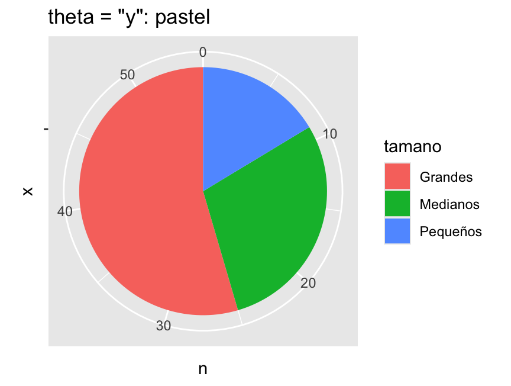

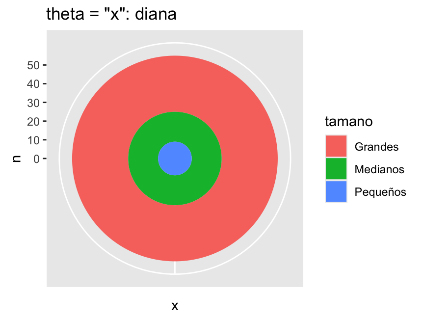

```r
tatuajes <- data.frame(tamano = c("Grandes", "Medianos", "Pequeños"),
                       n = c(30, 16, 9))

ggplot(tatuajes, aes(x = "", y = n, fill = tamano)) +
  geom_col(width = 1) +
  coord_polar(theta = "y") +
  labs(title = 'theta = "y": pastel')
ggplot(tatuajes, aes(x = "", y = n, fill = tamano)) +
  geom_col(width = 1) +
  coord_polar(theta = "x") +
  labs(title = 'theta = "x": diana')
```

El `x = ""` del pastel pone **todas** las filas en la misma posición del eje `x`: así queda una sola barra apilada, que después se enrolla.

### `scale_x_log10()` y `scale_y_log10()`: escala logarítmica

En una escala logarítmica, cada marca del eje vale **diez veces** la anterior (1, 10, 100, 1000…). Sirve para variables **numéricas positivas** que van de valores muy chicos a muy grandes, como el peso de un ratón y el de un braquiosaurio.

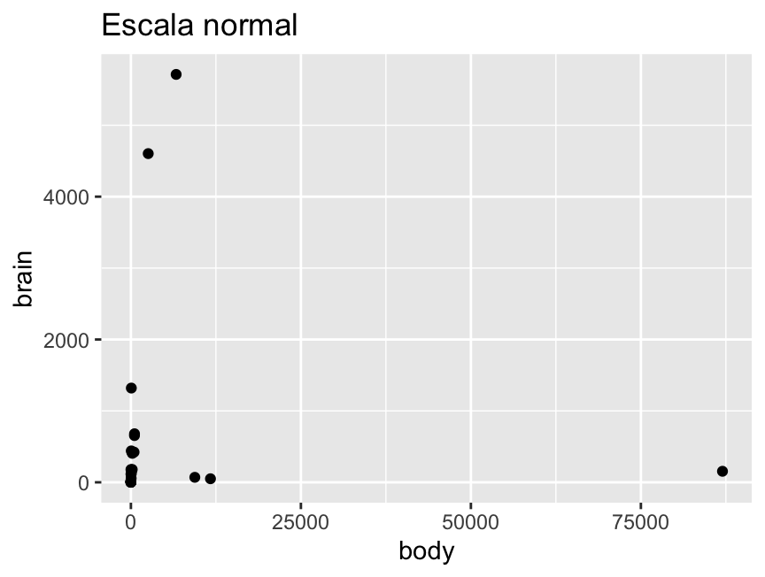

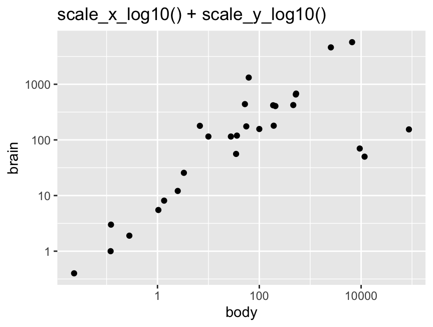

```r
ggplot(Animals, aes(x = body, y = brain)) +
  geom_point() +
  labs(title = "Escala normal")
ggplot(Animals, aes(x = body, y = brain)) +
  geom_point() +
  scale_x_log10() +
  scale_y_log10() +
  labs(title = "scale_x_log10() + scale_y_log10()")
```

La diferencia con escribir `aes(x = log10(body))`: el resultado se ve igual, pero con la **escala** los números del eje siguen en kilos y gramos (1, 100, 10000); con `log10()` el eje muestra el logaritmo (0, 2, 4), que hay que traducir de cabeza. Con ceros o negativos no funciona ninguna de las dos: el logaritmo de 0 no existe.

## 7. Los textos y el aspecto: `labs()`, `theme()` y `theme_void()`

### `labs()`: los títulos

| Argumento | Qué escribe |
| --- | --- |
| `x`, `y` | el título de cada eje |
| `title`, `subtitle` | el título y el subtítulo de la gráfica |
| `caption` | una nota al pie (por ejemplo, la fuente de los datos) |
| `fill`, `color` | el título de la **leyenda** de esa estética |

El nombre del argumento de la leyenda debe ser **el de la estética mapeada**: si el color viene de `fill = sexo`, el título se cambia con `labs(fill = ...)`, no con `labs(color = ...)`.

Escribir `NULL` **quita** el título: `labs(y = NULL)`. Y `\n` dentro del texto parte la línea en dos, útil para títulos de eje largos.

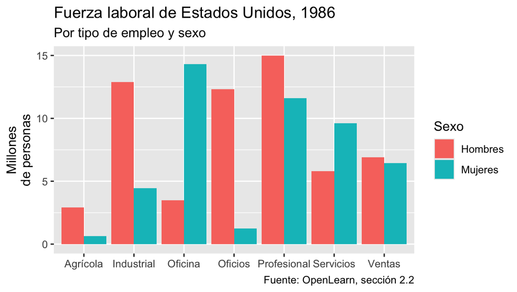

```r
ggplot(empleo, aes(x = tipo, y = millones, fill = sexo)) +
  geom_col(position = "dodge") +
  labs(title = "Fuerza laboral de Estados Unidos, 1986",
       subtitle = "Por tipo de empleo y sexo",
       x = NULL,                        # sin título en el eje x
       y = "Millones\nde personas",     # \n parte la línea
       fill = "Sexo",                   # título de la leyenda de fill
       caption = "Fuente: OpenLearn, sección 2.2")
```

### `theme()` y `element_text()`: girar los nombres de un eje

`theme()` controla todo lo que **no son datos**: textos, fondo, cuadrícula, leyenda. Cada pieza se cambia con una función `element_*()`. La que usa el notebook gira los nombres del eje `x` cuando son largos y se enciman:

- `axis.text.x`: los nombres (las etiquetas) del eje `x`.
- `element_text(angle = 30)`: los gira 30 grados.
- `hjust = 1`: alinea el **final** del texto con su marca del eje; sin él, el texto girado queda corrido y no se sabe a qué barra pertenece.

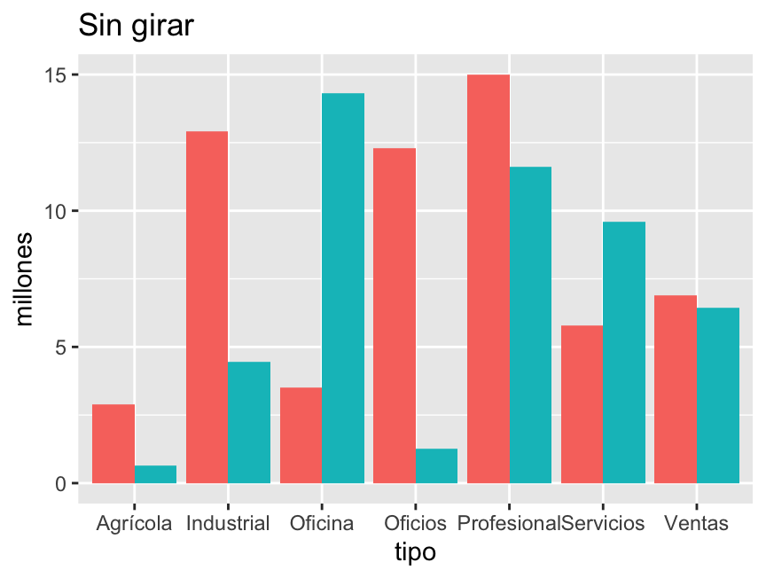

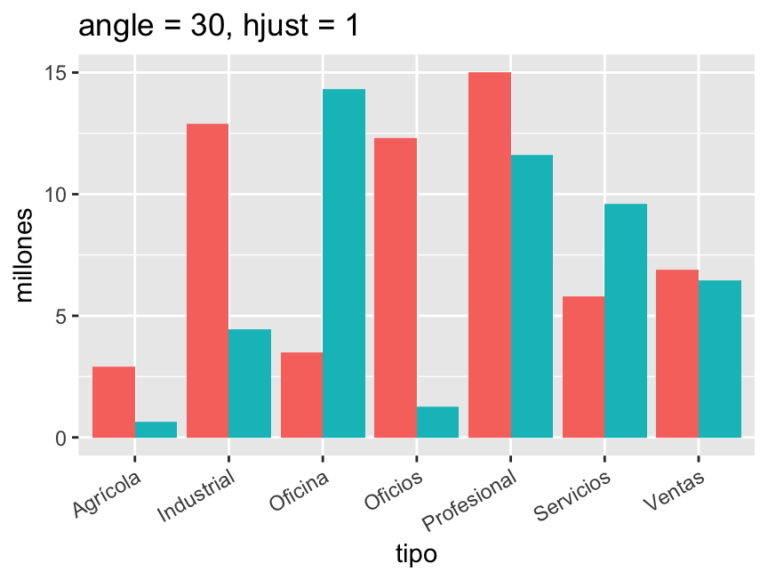

```r
base <- ggplot(empleo, aes(x = tipo, y = millones, fill = sexo)) +
  geom_col(position = "dodge") +
  theme(legend.position = "none") # sin leyenda, para comparar solo el eje

base + labs(title = "Sin girar")
base + theme(axis.text.x = element_text(angle = 30, hjust = 1)) +
  labs(title = "angle = 30, hjust = 1")
```

### `theme_void()` contra los demás temas completos

Un **tema completo** cambia el aspecto entero de una vez. `theme_void()` quita **todo**: ejes, números, cuadrícula y fondo. Solo se usa cuando los ejes no significan nada, como en un pastel. En una gráfica de barras o de dispersión, quitar los ejes deja al lector sin forma de leer los valores.

| Tema | Qué deja | Cuándo |
| --- | --- | --- |
| `theme_gray()` (por omisión) | fondo gris y cuadrícula blanca | exploración |
| `theme_minimal()` | sin fondo, cuadrícula suave | presentaciones y artículos |
| `theme_classic()` | solo las líneas de los ejes, sin cuadrícula | artículos |
| `theme_void()` | nada | pasteles y diagramas sin ejes |

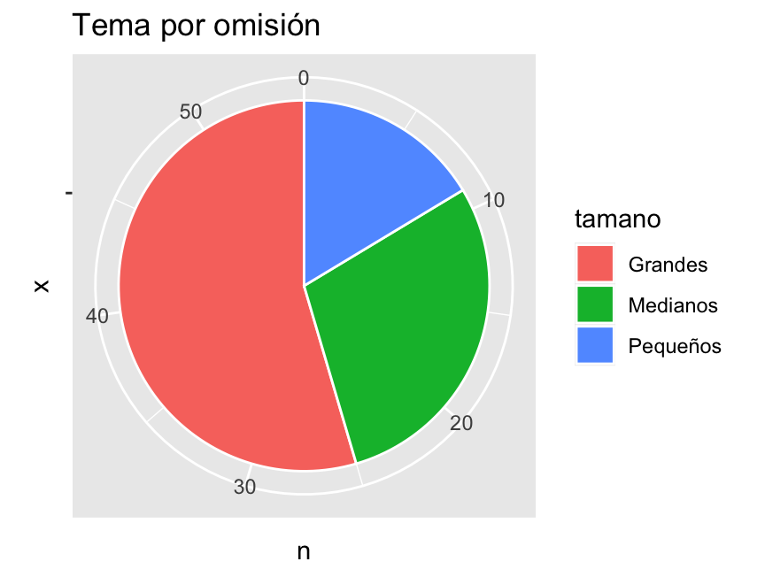

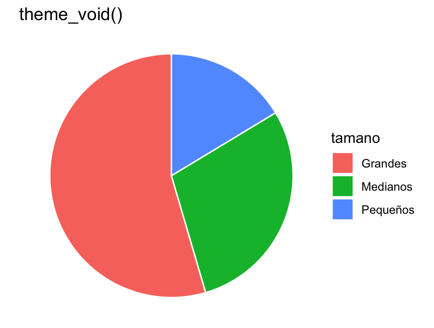

```r
pastel <- ggplot(tatuajes, aes(x = "", y = n, fill = tamano)) +
  geom_col(width = 1, color = "white") +
  coord_polar(theta = "y")

pastel + labs(title = "Tema por omisión")
pastel + theme_void() + labs(title = "theme_void()")
```

Los temas completos van **antes** de los `theme()` propios: si se escribe `theme(...)` y después `theme_void()`, el tema completo **borra** lo que hizo el `theme()` anterior.

## Resumen: qué argumento, con qué variable

| Argumento | Dónde va | Tipo de variable | Se confunde con | La diferencia |
| --- | --- | --- | --- | --- |
| `fill` | `aes()` o la capa | categórica o numérica | `color` | `fill` rellena; `color` es borde (barras) o color (puntos, texto) |
| `color` | `aes()` o la capa | categórica o numérica | `fill` | ídem |
| `size` | `aes()` o la capa | numérica | `linewidth` | `size`: puntos y texto; `linewidth`: líneas y bordes |
| `alpha` | `aes()` o la capa | numérica (0 a 1) | — | transparencia |
| `label` | `aes()` | cualquiera | — | solo para `geom_text()` |
| `width` | la capa | — (número de 0 a 1) | `width` de `geom_jitter()` | en barras es el ancho; en jitter, cuánto se mueve |
| `position` | `geom_col()`, `geom_bar()` | — | — | `"stack"`, `"dodge"`, `"fill"` |
| `bins` | `geom_histogram()` | `x` numérica | `binwidth` | cuántos intervalos contra qué tan anchos |
| `height` | `geom_jitter()` | — | — | con `y` numérica, siempre 0 |
| `outlier.shape` | `geom_boxplot()` | — | — | `NA` solo si hay puntos encima |
| `hjust`, `vjust` | `geom_text()`, `element_text()` | — | — | 0 empieza, 0.5 centra, 1 termina |
| `reorder()` | dentro de `aes()` | categórica, según una numérica | `factor(levels = )` | orden por los datos contra orden escrito a mano |
| `xlim()`, `ylim()` | capa aparte | numérica | `coord_cartesian()` | `xlim()` borra datos; `coord_cartesian()` solo acerca |
| `theta` | `coord_polar()` | — | — | `"y"` da pastel; `"x"`, diana |
| `scale_x_log10()` | capa aparte | numérica positiva | `log10()` en `aes()` | la escala conserva las unidades en el eje |
| `labs()` | capa aparte | — | `ggtitle()`, `xlab()` | `labs()` cambia todos los títulos a la vez |
| `theme()` | capa aparte | — | `theme_*()` | `theme()` cambia una pieza; `theme_*()`, todo el aspecto |

## Referencias

- Wickham, H., Navarro, D. y Pedersen, T. L. *ggplot2: Elegant Graphics for Data Analysis* (3.ª ed., versión en línea). https://ggplot2-book.org/
- Documentación de ggplot2: https://ggplot2.tidyverse.org/reference/
- Datos: The Open University, *Exploring data: graphs and numerical summaries*, OpenLearn; `birthwt` y `Animals`, en Venables, W. N. y Ripley, B. D. (2002). *Modern Applied Statistics with S*. Springer.